# Assessment 1

Daniel Godoy

unzip file

```r
unzip("activity.zip", exdir="activitymonitoringdata")
activity.base <- read.csv("activitymonitoringdata/activity.csv")
head(activity.base, 10)
```

```
##    steps       date interval
## 1     NA 2012-10-01        0
## 2     NA 2012-10-01        5
## 3     NA 2012-10-01       10
## 4     NA 2012-10-01       15
## 5     NA 2012-10-01       20
## 6     NA 2012-10-01       25
## 7     NA 2012-10-01       30
## 8     NA 2012-10-01       35
## 9     NA 2012-10-01       40
## 10    NA 2012-10-01       45
```

##### 1) What is mean total number of steps taken per day?

For this part of the assignment, you can ignore the missing values in the dataset.

Calculate the total number of steps taken per day

```r
total.steps.day <- aggregate(. ~ date, activity.base, FUN = sum, na.rm=TRUE)
head(total.steps.day)
```

```
##         date steps interval
## 1 2012-10-02   126   339120
## 2 2012-10-03 11352   339120
## 3 2012-10-04 12116   339120
## 4 2012-10-05 13294   339120
## 5 2012-10-06 15420   339120
## 6 2012-10-07 11015   339120
```

###### Make a histogram of the total number of steps taken each day

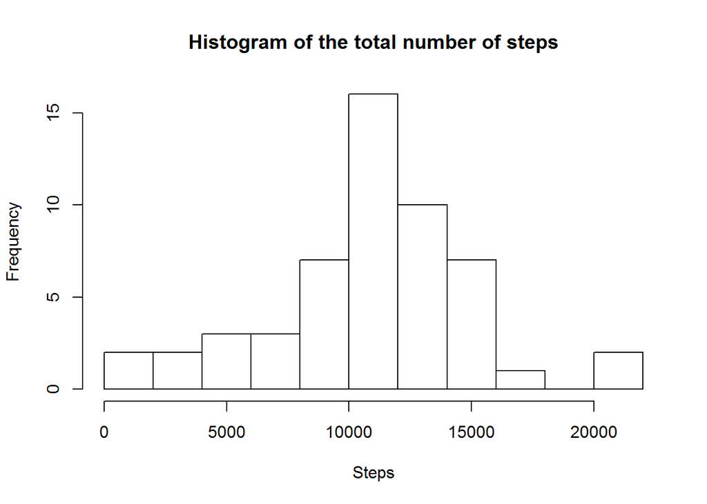

```r
hist(total.steps.day$steps, breaks="FD", xlab="Steps",
     main = "Histogram of the total number of steps")
```

##### Calculate and report the mean and median of the total number of steps taken per day

In this case the mean is represented in the graph by a red line and the median is represented in the graph by a dashed blue line.

```r
mean.steps.day <- mean(total.steps.day$steps)
median.steps.day <- median(total.steps.day$steps)
#Print mean
mean.steps.day
```

```
## [1] 10766.19
```

```r
#Print median
median.steps.day
```

```
## [1] 10765
```

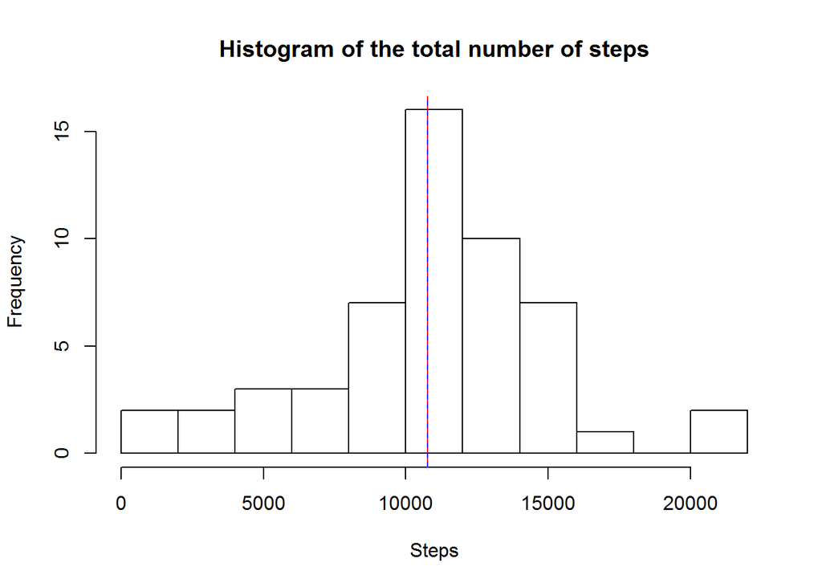

```r
hist(total.steps.day$steps, breaks="FD", xlab="Steps",
     main = "Histogram of the total number of steps", abline = 1000)
abline(v=mean.steps.day, col="red")
abline(v=median.steps.day, col="blue", lty="dashed")
```

##### What is the average daily activity pattern?

###### Make a time series plot (i.e. type = “l”) of the 5-minute interval (x-axis) and the average number of steps taken, averaged across all days (y-axis)

```r
average.steps.interval <- aggregate(. ~ interval, activity.base[ , -2], FUN = mean, na.rm=TRUE)
head(average.steps.interval)
```

```
##   interval     steps
## 1        0 1.7169811
## 2        5 0.3396226
## 3       10 0.1320755
## 4       15 0.1509434
## 5       20 0.0754717
## 6       25 2.0943396
```

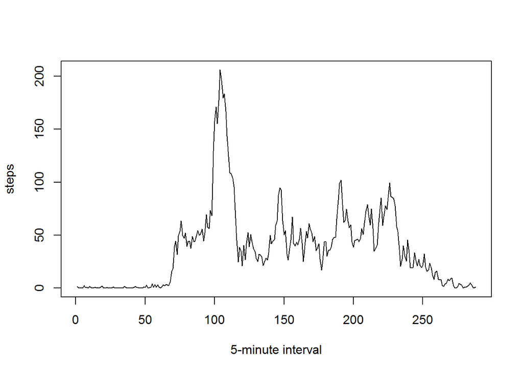

```r
plot(average.steps.interval$steps, type="l", xlab="5-minute interval",
                                        ylab = "steps")
```

```r
which.max(average.steps.interval$steps)
```

```
## [1] 104
```

###### Which 5-minute interval, on average across all the days in the dataset, contains the maximum number of steps?

```r
which.max(average.steps.interval$steps)
```

```
## [1] 104
```

##### Imputing missing values

###### Calculate and report the total number of missing values in the dataset (i.e. the total number of rows with NAs)

```r
sum(is.na(activity.base))
```

```
## [1] 2304
```